# Simple steps to improve reproducibility of your  computational research

```
Stephen J Eglen                  Cambridge Computational Biology Institute
https://sje30.github.io          University of Cambridge
sje30@cam.ac.uk                  @StephenEglen
```

Slides: http://bit.ly/eglen2018-rse (CC-BY license)

#### Acknowledgements

Paul Charlseworth, Ellese Cotterill, Catherine Cutts, Tom Edinburgh,
BBSRC, EPSRC, Wellcome Trust, Software Sustainability Institute.

# The reproducibility crisis

Many key findings in publications are either not independently
verified, or fail verification when it is attempted (Baker, 2016).
<a href="http://dx.doi.org/10.1038/533452a">10.1038/533452a</a>

Duke oncogenomics scandal.  Awesome detective work by Keith Baggerley
and Kevin Coombes.
<https://www.youtube.com/watch?v=7gYIs7uYbMo>

Disclaimer: do I mean "reproducibility" or "replicability"?
(Barba 2018) <https://arxiv.org/pdf/1802.03311.pdf>

# Inverse problems are hard

<table>
 <thead>
  <tr>
   <th style="text-align:left;"> Mark </th>
   <th style="text-align:left;"> grade </th>
  </tr>
 </thead>
<tbody>
  <tr>
   <td style="text-align:left;"> 70-100 </td>
   <td style="text-align:left;"> A </td>
  </tr>
  <tr>
   <td style="text-align:left;"> 60-69 </td>
   <td style="text-align:left;"> B </td>
  </tr>
  <tr>
   <td style="text-align:left;"> 50-59 </td>
   <td style="text-align:left;"> C </td>
  </tr>
  <tr>
   <td style="text-align:left;"> 40-49 </td>
   <td style="text-align:left;"> D </td>
  </tr>
  <tr>
   <td style="text-align:left;"> 0-39 </td>
   <td style="text-align:left;"> F </td>
  </tr>
</tbody>
</table>

### Forward problem

I scored 68, what was my grade?

### Inverse problem

I got a B, what was my score?

# Research sharing: the inverse problem

[figure not shown]

# Where is the scholarship?

> An article about computational science in a scientific publication
> is not the scholarship itself, it is merely advertising of the
> scholarship. The actual scholarship is the complete software
> development environment and that complete set of instructions that
> generated the figures.

[Buckheit and Donoho 1995, after Claerbout]

10.1007/978-1-4612-2544-7_5

# Moral or selfish approach?

[figure not shown]

10.1186/s13059-015-0850-7

# Selfish reasons to share

Why not align what is good for science with what is good for
scientists?

1. Funding mandates (REF + enforcement from Wellcome Trust)
2. Credit through data papers
3. Fixes data bugs / errors in analysis
4. Prevent data loss [(Vines et al 2014)](http://www.ncbi.nlm.nih.gov/pubmed/24361065). e.g. students have a habit of leaving...
5. Your future self is probably one of the main beneficiaries of
   sharing.
6. *Now* is a very good time to be an open scientist.
7. Leads to further collaborations
8. Reviewers can do more work...

# meaRtools: Tools for MEA analysis

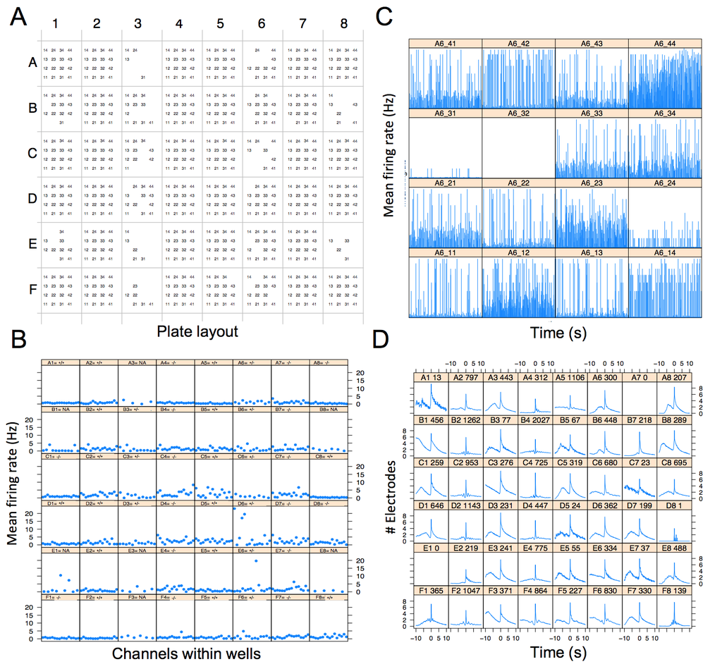

10.1101/242065

# Reviewers doing your work

I would use an ordinate log scale for this bottom right panel (as
    done in Fig.  3). But since the authors gave me everything, I can
    do it! by redefining fourplot as follows:

[figure not shown]

#

# Code review pilot

[figure not shown]

10.1038/nn.4550

# Specific recommendations

1. Include enough code to reproduce key figure/result from your paper
   ("modeldb").
2. Provide toy examples if your project is too intensive to expect
   others to run in a few hours.
3. Version control (github)
4. Licence (MIT)
5. Provide data
6. Provide tests
7. Use standards
8. Use permanent URLs (Zenodo/figshare)

# Simple example of reproducible research

Eglen SJ (2016) Bivariate spatial point patterns in the retina: a
reproducible review. Journal de la Société Française de Statistique
157:33–48.

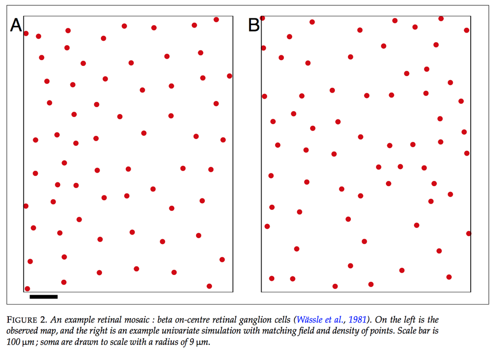

See

[paper](https://doi.org/10.1101/029348)
or [code](http://github.com/sje30/eglen2015).  [Docker image](https://hub.docker.com/r/sje30/eglen2015/).

# New tools

1. **Docker** Can bundle entire open-source evironment for others to share.
2. Jupyter notebooks
3. binder = Docker + jupyter + cloud compute
4. Code ocean, and alternatives, being supported by some journal publishers,
   e.g. CUP.

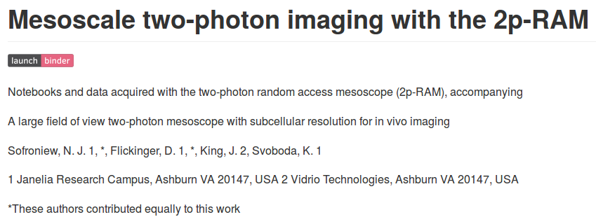

[https://github.com/sofroniewn/2pRAM-paper](https://github.com/sofroniewn/2pRAM-paper)

# Binder example for teaching

Two hour introduction to computational neuroscience (this Thursday if
anyone is interested...)

[Binder](https://mybinder.org/v2/gh/sje30/julia-python/master?filepath=Introduction%20to%20Computational%20Neuroscience.ipynb)
[Github](https://github.com/sje30/julia-python)

# Find a code buddy

* We ask our students to submit a .Rnw file rather than a pdf.  You get
a zero if I can't compile the pdf.
* So, ask someone else if they can run your code.
* Bioconductor team performs code review
* Journals gradually moving in this direction

# Third most important file in github repo?

Credit: Arfon Smith

* First: LICENSE

* Second: README.md

* Third: Makefile

# Make

Make (or SnakeMake) are great at reducing cognitive load.

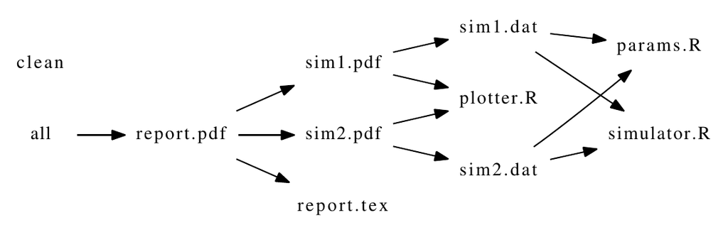

```r
report.pdf: report.tex sim1.pdf sim2.pdf
	texi2pdf report.tex

sim1.dat: params.R simulator.R
	Rscript simulator.R rnorm > sim1.dat

sim2.dat: params.R simulator.R
	Rscript simulator.R runif > sim2.dat

sim1.pdf: sim1.dat plotter.R
	Rscript plotter.R sim1.dat

sim2.pdf: sim2.dat plotter.R
	Rscript plotter.R sim2.dat


.PHONY: all clean

all: report.pdf

clean:
	rm -f report.pdf report.log report.aux
	rm -f sim1.* sim2*
```

## Reproducible figures

```r
library(ggplot2); library(patchwork) # github.com/thomasp85/patchwork
p1 = ggplot(mtcars) + geom_point(aes(mpg, disp)) + labs(tag="A")
p2 = ggplot(mtcars) +
  geom_boxplot(aes(gear, disp, group = gear)) + labs(tag="B")
p3 = ggplot(mtcars) + geom_smooth(aes(disp, qsec)) + labs(tag="C")
p4 = ggplot(mtcars) + geom_bar(aes(carb)) + labs(tag="D")
((p1 | p2 | p3) /  p4 ) + theme_bw()
```

[figure not shown]

# Summary

* Find the selfish reasons to make your research reproducible.
* Adopt good practices to help you on your way.
* Writing code in groups can be very motivating.
* Use new tech if you want, but old tech works too.

# Challenges

* Long computation times (CODE CHECK).
* licensed software complicates everything.
* Can journals handle reproducible documents?
* When is the best time to think reproducibly?
   - Too early (explore  first)
   - Too late (paper now out)?
* Technical challenges << Societal challenges